# Executive Summary and Approach

### Executive Summary and Approach

#### Executive Summary

The Coursera Practical Machine Learning course project focused on evaluating a dataset consisting of accelerometer, gyro, and magneto data points for a weight lifting fitness experiement. The objective of the evaluation was to train a machine learning algorithm to predict 20 outcomes.

Data Source and original study: http://groupware.les.inf.puc-rio.br/har

#### Approach

The objective of this project was to develop the best model for predicting the quality of weight lifting exercises based upon the data sets provided. Developing the prediction model for the data set consisted of several key phases.

1. Establish the Machine Learning study
2. Execute Exploratory Data Analysis
3. Build and Test the Model against training and validation sets
4. Analyze and select the best fit Model
5. Predict the outcomes of the test set

### Machine Learning design

The Machine Learning algorithm was designed applying an interative approach to model training and analyzing the error rates. This iterative approach addressed the risk of over-fitting and model issues by applying a cross-validation methodology.

The goal of each iteration was to develop a separate independent model from a training set. Each iteration was evaluated based on error rate. The model with the best error rate was selected. The training and testing sets used in each iteration were derrived by splitting the overall training data using a 70:30 ratio. The following outlines the steps performed within each iteration:

- Acquisition of cross-validated training and testing sets
- Data preprocessing and cleansing
- Feature Development
- Model design and build
- Model evaluation against test set
- Fit Analysis based on error rate

### Exploratory Data Analysis (EDA)

The first preparation step during EDA was to obtain the training data set from its source (labelled training.MasterData), and partition it into training and testing sets.

The EDA phase then proceeded with several analysis steps:

- View Data
- Explore like-data
- Conclusion

#### View Data

1. Underlying structure
   - The training data was inspected for structure and class. From the 160 variables noted, 7 were considered metadata and 100 were noted as statistical data from previous pre-processing.
- Given that the objective of the project is to predict the quality of exercise based upon specific measured data, all metadata and other pre-processed data was removed.
1. Understanding Dumbbell movement

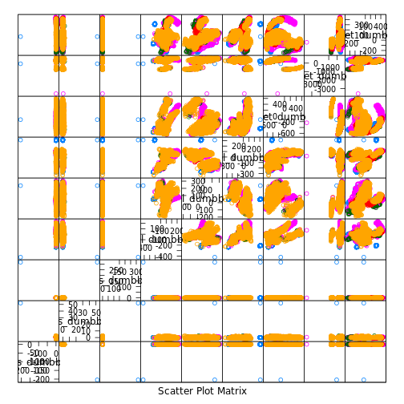

2. Dumbbell y movement per accelerometer

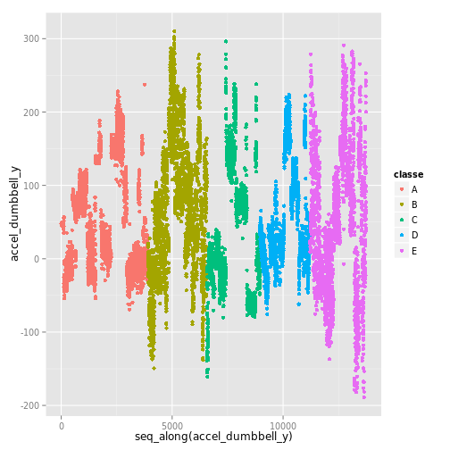

#### Explore like-data

The objective of exploring like data was to identify whether features can be adjusted or new features created due to their interaction or relationship. This part focused on reviewing near zero variance and correlated predictors.

1. Near zero variance

```
##                      freqRatio percentUnique zeroVar   nzv
## roll_belt             1.178752    7.88381743   FALSE FALSE
## pitch_belt            1.028986   12.22974449   FALSE FALSE
## yaw_belt              1.046832   13.01594235   FALSE FALSE
## total_accel_belt      1.063331    0.20382907   FALSE FALSE
## gyros_belt_x          1.067016    0.90267162   FALSE FALSE
## gyros_belt_y          1.133610    0.44405620   FALSE FALSE
## gyros_belt_z          1.068016    1.20113562   FALSE FALSE
## accel_belt_x          1.023810    1.13561913   FALSE FALSE
## accel_belt_y          1.143266    0.95362889   FALSE FALSE
## accel_belt_z          1.066129    2.11108685   FALSE FALSE
## magnet_belt_x         1.087302    2.18388294   FALSE FALSE
## magnet_belt_y         1.155251    2.11836646   FALSE FALSE
## magnet_belt_z         1.100946    3.13023222   FALSE FALSE
## roll_arm             52.239130   17.59481692   FALSE FALSE
## pitch_arm            72.848485   20.01892699   FALSE FALSE
## yaw_arm              33.375000   18.97794278   FALSE FALSE
## total_accel_arm       1.015432    0.46589503   FALSE FALSE
## gyros_arm_x           1.010959    4.56431535   FALSE FALSE
## gyros_arm_y           1.498567    2.69345563   FALSE FALSE
## gyros_arm_z           1.157459    1.68886948   FALSE FALSE
## accel_arm_x           1.033058    5.56890151   FALSE FALSE
## accel_arm_y           1.222973    3.83635437   FALSE FALSE
## accel_arm_z           1.010309    5.56890151   FALSE FALSE
## magnet_arm_x          1.032258    9.56540729   FALSE FALSE
## magnet_arm_y          1.200000    6.20950717   FALSE FALSE
## magnet_arm_z          1.038961    9.12135110   FALSE FALSE
## roll_dumbbell         1.041667   86.58367911   FALSE FALSE
## pitch_dumbbell        2.260417   84.26876319   FALSE FALSE
## yaw_dumbbell          1.156627   85.95035306   FALSE FALSE
## total_accel_dumbbell  1.071429    0.31302322   FALSE FALSE
## gyros_dumbbell_x      1.025057    1.68886948   FALSE FALSE
## gyros_dumbbell_y      1.212264    1.92909660   FALSE FALSE
## gyros_dumbbell_z      1.054374    1.45592196   FALSE FALSE
## accel_dumbbell_x      1.081448    3.02103807   FALSE FALSE
## accel_dumbbell_y      1.030120    3.33406129   FALSE FALSE
## accel_dumbbell_z      1.153409    2.89728471   FALSE FALSE
## magnet_dumbbell_x     1.055556    7.81102133   FALSE FALSE
## magnet_dumbbell_y     1.225806    6.02023732   FALSE FALSE
## magnet_dumbbell_z     1.051471    4.83366092   FALSE FALSE
## roll_forearm         12.313636   13.83125864   FALSE FALSE
## pitch_forearm        61.568182   19.13081459   FALSE FALSE
## yaw_forearm          14.559140   12.88490937   FALSE FALSE
## total_accel_forearm   1.151620    0.50229308   FALSE FALSE
## gyros_forearm_x       1.128492    2.07468880   FALSE FALSE
## gyros_forearm_y       1.135659    5.26315789   FALSE FALSE
## gyros_forearm_z       1.083573    2.14748489   FALSE FALSE
## accel_forearm_x       1.041667    5.64897721   FALSE FALSE
## accel_forearm_y       1.042254    7.16313606   FALSE FALSE
## accel_forearm_z       1.026786    4.10569993   FALSE FALSE
## magnet_forearm_x      1.000000   10.53359540   FALSE FALSE
## magnet_forearm_y      1.233333   13.32168596   FALSE FALSE
## magnet_forearm_z      1.022727   11.63281648   FALSE FALSE
## classe                1.469526    0.03639805   FALSE FALSE
```

It appears none of the existing features had near zero variance.

1. Correlated predictors (Training features with correlations greater than 0.9)

```
##                  row col
## total_accel_belt   4   1
## accel_belt_y       9   1
## accel_belt_z      10   1
## accel_belt_x       8   2
## roll_belt          1   4
## accel_belt_y       9   4
## accel_belt_z      10   4
## pitch_belt         2   8
## roll_belt          1   9
## total_accel_belt   4   9
## accel_belt_z      10   9
## roll_belt          1  10
## total_accel_belt   4  10
## accel_belt_y       9  10
## gyros_arm_y       19  18
## gyros_arm_x       18  19
## gyros_dumbbell_z  33  31
## gyros_forearm_z   46  31
## gyros_dumbbell_x  31  33
## gyros_forearm_z   46  33
## gyros_dumbbell_x  31  46
## gyros_dumbbell_z  33  46
```

Due to identification of correlated predictors, an extra step was added in the form of PCA analysis.

1. Identify interesting patterns via PCA (top 6 components only)

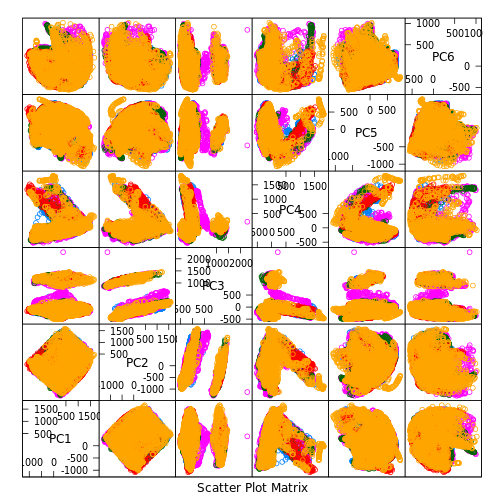

#### Concluding EDA

From this analysis, it appears that there were no linear relationships that could have helped predict which type of error (if any) is performed based on raw senor data. As such, the models most likely to succeed in training were classification -based.

### Model development comparison and selection

#### Model development

The model development phase was a structured stage of iterating through various models to find the best fit. The model candidates were:

- Linear & Quadradic discriminate analysis
- Recursive Partitioning and Regression Trees (rpart)
- Random Forests (rf)

- Model 1.0
  - No extra feature creation
  - Linear Discriminate Analysis (lda)
  - Tuning with 10-fold cross-validation

```
## [1] "Model 1 Accuracy:" "0.7025"
```

Due to the low accuracy, this model will be dropped from consideration.

- Model 2.0
  - No extra feature creation
  - Quadratic Discriminate Analysis (qda)
  - Tuning with 10-fold cross-validation

```
## [1] "Model 2 Accuracy:" "0.8941"
```

- Model 3.0
  - No extra feature creation
  - Recursive Partitioning and Regression Trees (rpart)
  - Tuning with 10-fold cross-validation

```
## [1] "Model 3 Accuracy:" "0.5042"            "0.425"
## [4] "0.324"
```

Due to the low accuracy, this model will be dropped from consideration.

- Model 4.0
  - No extra feature creation
  - Random Forest (rf)
  - No custom resampling

```
## [1] "Model 4 Accuracy:" "0.9879"            "0.9891"
## [4] "0.9813"
```

Due to the accuracy over 0.80, this model will be evaluated further.

#### Model Comparison and selection

The model selection part focused on applying the tuned model to the test data (note not the master test data, rather the test data partitioned from the master training set). The following confusion matrix resulted from this application.

```
## Confusion Matrix and Statistics
##
##           Reference
## Prediction    A    B    C    D    E
##          A 1671    1    0    0    2
##          B   10 1128    1    0    0
##          C    0    8 1009    9    0
##          D    0    0   15  949    0
##          E    0    0    3    1 1078
##
## Overall Statistics
##
##                Accuracy : 0.9915
##                  95% CI : (0.9888, 0.9937)
##     No Information Rate : 0.2856
##     P-Value [Acc > NIR] : < 2.2e-16
##
##                   Kappa : 0.9893
##  Mcnemar's Test P-Value : NA
##
## Statistics by Class:
##
##                      Class: A Class: B Class: C Class: D Class: E
## Sensitivity            0.9941   0.9921   0.9815   0.9896   0.9981
## Specificity            0.9993   0.9977   0.9965   0.9970   0.9992
## Pos Pred Value         0.9982   0.9903   0.9834   0.9844   0.9963
## Neg Pred Value         0.9976   0.9981   0.9961   0.9980   0.9996
## Prevalence             0.2856   0.1932   0.1747   0.1630   0.1835
## Detection Rate         0.2839   0.1917   0.1715   0.1613   0.1832
## Detection Prevalence   0.2845   0.1935   0.1743   0.1638   0.1839
## Balanced Accuracy      0.9967   0.9949   0.9890   0.9933   0.9987
```

### Conclusion

The Random Forest model number 4 that was selected to predict the classe outcome from the master test set. The following function was applied to produce the results.

```r
# testing.Master <- read.csv("./pml-testing.csv")
# answers <- predict(model4,testing.Master)
# pml_write_files(as.character(answers))
```

### Appendix and other reference items

Note that the answers were not generated as a part of this file.

- Full model results

```
## Linear Discriminant Analysis
##
## 13737 samples
##    52 predictor
##     5 classes: 'A', 'B', 'C', 'D', 'E'
##
## No pre-processing
## Resampling: Cross-Validated (10 fold, repeated 10 times)
##
## Summary of sample sizes: 12363, 12363, 12363, 12364, 12365, 12365, ...
##
## Resampling results
##
##   Accuracy   Kappa     Accuracy SD  Kappa SD
##   0.7024807  0.623546  0.0120308    0.01531549
##
##
```

```
## Quadratic Discriminant Analysis
##
## 13737 samples
##    52 predictor
##     5 classes: 'A', 'B', 'C', 'D', 'E'
##
## No pre-processing
## Resampling: Cross-Validated (10 fold, repeated 10 times)
##
## Summary of sample sizes: 12363, 12364, 12363, 12362, 12364, 12366, ...
##
## Resampling results
##
##   Accuracy   Kappa     Accuracy SD  Kappa SD
##   0.8940831  0.866245  0.007636358  0.009626202
##
##
```

```
## CART
##
## 13737 samples
##    52 predictor
##     5 classes: 'A', 'B', 'C', 'D', 'E'
##
## No pre-processing
## Resampling: Cross-Validated (10 fold, repeated 10 times)
##
## Summary of sample sizes: 12362, 12363, 12365, 12364, 12362, 12364, ...
##
## Resampling results across tuning parameters:
##
##   cp          Accuracy   Kappa       Accuracy SD  Kappa SD
##   0.03173634  0.5042095  0.35065669  0.03462171   0.05523738
##   0.05950565  0.4249554  0.22412543  0.06037952   0.10191261
##   0.11738379  0.3240234  0.06074527  0.03993234   0.06115216
##
## Accuracy was used to select the optimal model using  the largest value.
## The final value used for the model was cp = 0.03173634.
```

```
## Random Forest
##
## 13737 samples
##    52 predictor
##     5 classes: 'A', 'B', 'C', 'D', 'E'
##
## No pre-processing
## Resampling: Bootstrapped (25 reps)
##
## Summary of sample sizes: 13737, 13737, 13737, 13737, 13737, 13737, ...
##
## Resampling results across tuning parameters:
##
##   mtry  Accuracy   Kappa      Accuracy SD  Kappa SD
##    2    0.9879070  0.9846982  0.001895215  0.002392504
##   27    0.9891334  0.9862510  0.001832207  0.002315964
##   52    0.9812697  0.9763010  0.003763937  0.004755336
##
## Accuracy was used to select the optimal model using  the largest value.
## The final value used for the model was mtry = 27.
```

- Model run performance
  - The final model set was run on an AWS image running 16-cores and 30 GB RAM. The following lists the time each model took to run. The first several models ran equally quickly between desktop and server instances.

```
##    user  system elapsed
##   1.430   0.053  26.101
```

```
##    user  system elapsed
##   1.264   0.069  25.133
```

```
##    user  system elapsed
##   5.935   0.069  43.658
```

```
##    user  system elapsed
##  45.868   0.192 496.287
```

- Full data structure (hidden from knitr output - refer to Rmd file)